# Practical Machine Learning course project

## Appendix D - Detail of Importance analysis

#### Top 17 variables model with 500 trees

```r
print(rf17final)
```

```
##
## Call:
##  randomForest(formula = classe ~ roll_belt + yaw_belt + pitch_forearm +      magnet_dumbbell_z + pitch_belt + magnet_dumbbell_y + roll_forearm +      magnet_dumbbell_x + accel_dumbbell_y + roll_dumbbell + accel_dumbbell_y +      accel_belt_z + magnet_belt_z + accel_forearm_x + accel_dumbbell_z + …
##                Type of random forest: classification
##                      Number of trees: 500
## No. of variables tried at each split: 3
##
##         OOB estimate of  error rate: 1.21%
## Confusion matrix:
##      A    B    C    D    E class.error
## A 3341    4    1    1    1 0.002090800
## B   18 2227   33    1    0 0.022817025
## C    0   22 2020   12    0 0.016553067
## D    1    1   26 1899    3 0.016062176
## E    0    5    6    8 2146 0.008775982
```

#### Top 17 variables model with 192 trees

```r
print(rf17.192final)
```

```
##
## Call:
##  randomForest(formula = classe ~ roll_belt + yaw_belt + pitch_forearm +      magnet_dumbbell_z + pitch_belt + magnet_dumbbell_y + roll_forearm +      magnet_dumbbell_x + accel_dumbbell_y + roll_dumbbell + accel_dumbbell_y +      accel_belt_z + magnet_belt_z + accel_forearm_x + accel_dumbbell_z + …
##                Type of random forest: classification
##                      Number of trees: 192
## No. of variables tried at each split: 3
##
##         OOB estimate of  error rate: 1.38%
## Confusion matrix:
##      A    B    C    D    E class.error
## A 3334    8    5    1    0 0.004181601
## B   21 2220   36    2    0 0.025888548
## C    0   23 2016   15    0 0.018500487
## D    0    3   25 1901    1 0.015025907
## E    0    6    6   10 2143 0.010161663
```

#### Top 7 variables model with 500 trees

```r
print(rf7final)
```

```
##
## Call:
##  randomForest(formula = classe ~ roll_belt + yaw_belt + pitch_forearm +      magnet_dumbbell_z + pitch_belt + magnet_dumbbell_y + roll_forearm,      data = training, importance = TRUE)
##                Type of random forest: classification
##                      Number of trees: 500
## No. of variables tried at each split: 2
##
##         OOB estimate of  error rate: 1.74%
## Confusion matrix:
##      A    B    C    D    E class.error
## A 3299   18   26    5    0  0.01463560
## B   18 2209   40   11    1  0.03071523
## C    3   13 2023   15    0  0.01509250
## D    0    5   19 1903    3  0.01398964
## E    1   16    7    4 2137  0.01293303
```

#### Top 7 variables model with 192 trees

```r
print(rf7.192final)
```

```
##
## Call:
##  randomForest(formula = classe ~ roll_belt + yaw_belt + pitch_forearm +      magnet_dumbbell_z + pitch_belt + magnet_dumbbell_y + roll_forearm,      data = training, importance = TRUE, ntree = 192)
##                Type of random forest: classification
##                      Number of trees: 192
## No. of variables tried at each split: 2
##
##         OOB estimate of  error rate: 1.78%
## Confusion matrix:
##      A    B    C    D    E class.error
## A 3300   18   26    4    0  0.01433692
## B   18 2209   40   12    0  0.03071523
## C    3   18 2017   16    0  0.01801363
## D    0    5   20 1903    2  0.01398964
## E    1   16    6    5 2137  0.01293303
```

## Appendix E - Creation of box plots of variables per classe

```r
p1  <- ggplot(training, aes(x=classe, y=roll_belt, fill=classe)) +
        geom_boxplot() + guides(fill=FALSE)
p2  <- ggplot(training, aes(x=classe, y=yaw_belt, fill=classe)) +
        geom_boxplot() + guides(fill=FALSE)
p3  <- ggplot(training, aes(x=classe, y=pitch_forearm, fill=classe)) +
        geom_boxplot() + guides(fill=FALSE)
p4  <- ggplot(training, aes(x=classe, y=magnet_dumbbell_z, fill=classe)) +
        geom_boxplot() + guides(fill=FALSE)
p5  <- ggplot(training, aes(x=classe, y=pitch_belt, fill=classe)) +
        geom_boxplot() + guides(fill=FALSE)
p6  <- ggplot(training, aes(x=classe, y=magnet_dumbbell_y, fill=classe)) +
        geom_boxplot() + guides(fill=FALSE)
p7  <- ggplot(training, aes(x=classe, y=roll_forearm, fill=classe)) +
        geom_boxplot() + guides(fill=FALSE)
p8  <- ggplot(training, aes(x=classe, y=magnet_dumbbell_x, fill=classe)) +
        geom_boxplot() + guides(fill=FALSE)
p9  <- ggplot(training, aes(x=classe, y=accel_dumbbell_y, fill=classe)) +
        geom_boxplot() + guides(fill=FALSE)
p10 <- ggplot(training, aes(x=classe, y=roll_dumbbell, fill=classe)) +
        geom_boxplot() + guides(fill=FALSE)
p11 <- ggplot(training, aes(x=classe, y=magnet_belt_y, fill=classe)) +
        geom_boxplot() + guides(fill=FALSE)
p12 <- ggplot(training, aes(x=classe, y=magnet_belt_z, fill=classe)) +
        geom_boxplot() + guides(fill=FALSE)

# courtesy: http://www.cookbook-r.com/Graphs/Multiple_graphs_on_one_page_(ggplot2)
multiplot <- function(..., plotlist=NULL, file, cols=1, layout=NULL) {
    library(grid)
    plots <- c(list(...), plotlist)
    numPlots = length(plots)
    if (is.null(layout)) {
        layout <- matrix(seq(1, cols * ceiling(numPlots/cols)),
                         ncol = cols, nrow = ceiling(numPlots/cols))
    }
    if (numPlots==1) {
        print(plots[[1]])
    } else {
        grid.newpage()
        pushViewport(viewport(layout = grid.layout(nrow(layout), ncol(layout))))
        for (i in 1:numPlots) {
            matchidx <- as.data.frame(which(layout == i, arr.ind = TRUE))
            print(plots[[i]], vp = viewport(layout.pos.row = matchidx$row,
                                            layout.pos.col = matchidx$col))
        }
    }
}

multiplot(p1, p2, p3, p4, p5, p6, p7, p8, p9, p10, p11, p12,
          layout=matrix(c(1,2,3,4,5,6,7,8,9,10,11,12), nrow=3, byrow=TRUE))
```

[output not shown]

## Appendix F - examples of the Random Forest tree construction

These examples are of illustrative purpose only, the complex “black box” approach taken by Random Forest does not lend itself to any useful analysis of these kinds of tables and charts.

#### Extract of the first 48 decisions of the first Random Forest tree

```r
suppressPackageStartupMessages({
    library(rattle)
})
head(treeset.randomForest(rf17final, n=1, root=1, format="R"), 48)
```

```
##  [1] "if (magnet_belt_z <= -445.5)"    "if (roll_forearm <= -158)"
##  [3] "if (magnet_dumbbell_z <= 92)"    "Result <- E"
##  [5] "else"                            "if (accel_belt_z <= 7)"
##  [7] "Result <- D"                     "else"
##  [9] "Result <- B"                     "else"
## [11] "if (magnet_dumbbell_z <= 143)"   "if (roll_forearm <= 177.5)"
## [13] "Result <- E"                     "else"
## [15] "if (pitch_belt <= -1.52)"        "if (accel_forearm_x <= -16)"
## [17] "Result <- E"                     "else"
## [19] "Result <- D"                     "else"
## [21] "Result <- E"                     "else"
## [23] "if (pitch_belt <= 2.36)"         "Result <- D"
## [25] "else"                            "if (magnet_belt_z <= -447)"
## [27] "Result <- B"                     "else"
## [29] "Result <- C"                     "else"
## [31] "if (pitch_forearm <= -33.9)"     "if (magnet_dumbbell_z <= -74.5)"
## [33] "if (accel_forearm_x <= 112.5)"   "Result <- B"
## [35] "else"                            "Result <- A"
## [37] "else"                            "if (magnet_dumbbell_z <= -70.5)"
## [39] "if (yaw_belt <= -92.95)"         "Result <- A"
## [41] "else"                            "Result <- B"
## [43] "else"                            "Result <- A"
## [45] "else"                            "if (magnet_dumbbell_y <= 439.5)"
## [47] "if (yaw_belt <= 169.5)"          "if (roll_belt <= 130.5)"
```

#### Dendrogram of the first Random Forest tree

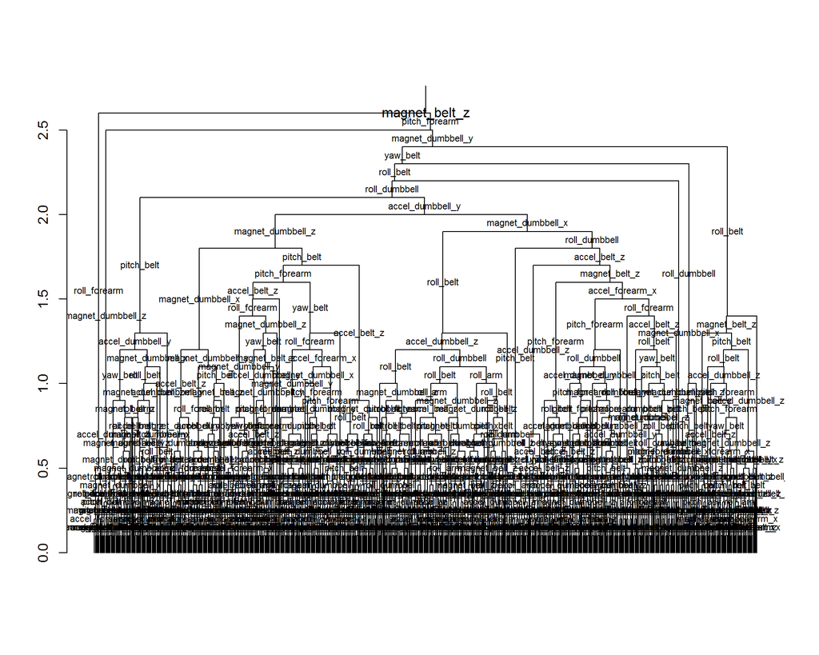

```r
# http://stats.stackexchange.com/questions/2344/best-way-to-present-a-random-forest-in-a-publication
to.dendrogram <- function(dfrep,rownum=1,height.increment=0.1){

    if(dfrep[rownum,'status'] == -1){
        rval <- list()

        attr(rval,"members") <- 1
        attr(rval,"height") <- 0.0
        attr(rval,"label") <- dfrep[rownum,'prediction']
        attr(rval,"leaf") <- TRUE

    }else{##note the change "to.dendrogram" and not "to.dendogram"
        left <- to.dendrogram(dfrep,dfrep[rownum,'left daughter'],height.increment)
        right <- to.dendrogram(dfrep,dfrep[rownum,'right daughter'],height.increment)
        rval <- list(left,right)

        attr(rval,"members") <- attr(left,"members") + attr(right,"members")
        attr(rval,"height") <- max(attr(left,"height"),attr(right,"height")) + height.increment
        attr(rval,"leaf") <- FALSE
        attr(rval,"edgetext") <- dfrep[rownum,'split var']
    }

    class(rval) <- "dendrogram"

    return(rval)
}

if(file.exists("rffinaltree.rds")) {
    tree <- readRDS("rffinaltree.rds")
} else {
    tree <- getTree(rf17final,1,labelVar=TRUE)
    saveRDS(tree, file = "rffinaltree.rds")
}

tree <- getTree(rf17final,1,labelVar=TRUE)
d <- to.dendrogram(tree)
plot(d,center=TRUE,leaflab='none',edgePar=list(t.cex=0.7,p.col=NA,p.lty=0))
```

## Appendix G - using train from the caret package

The same process was explored using train from the caret package. The results were similar but since building the model was very much longer (42 minutes vs just a few minutes required for randomForest), I decided to go with the more efficient method.

```r
if(file.exists("rfmodelCARET.rds")) {
    rfmodel <- readRDS("rfmodelCARET.rds")
} else {
    rfmodel <- train(classe~., data=training, method="rf", verbose=FALSE, type="none")
    saveRDS(rfmodel, file = "rfmodelCARET.rds")
}
print(rfmodel)
```

```
## Random Forest
##
## 11776 samples
##    53 predictor
##     5 classes: 'A', 'B', 'C', 'D', 'E'
##
## No pre-processing
## Resampling: Bootstrapped (25 reps)
## Summary of sample sizes: 11776, 11776, 11776, 11776, 11776, 11776, ...
## Resampling results across tuning parameters:
##
##   mtry  Accuracy   Kappa      Accuracy SD  Kappa SD
##    2    0.9849428  0.9809330  0.002420569  0.003065593
##   29    0.9873138  0.9839365  0.002165477  0.002741941
##   57    0.9800756  0.9747692  0.004130574  0.005239992
##
## Accuracy was used to select the optimal model using  the largest value.
## The final value used for the model was mtry = 29.
```

```r
print(rfmodel$finalModel)
```

```
##
## Call:
##  randomForest(x = x, y = y, mtry = param$mtry, verbose = FALSE,      type = "none")
##                Type of random forest: classification
##                      Number of trees: 500
## No. of variables tried at each split: 29
##
##         OOB estimate of  error rate: 0.85%
## Confusion matrix:
##      A    B    C    D    E class.error
## A 3340    6    1    0    1 0.002389486
## B   16 2253    9    1    0 0.011408513
## C    0   14 2032    8    0 0.010710808
## D    0    1   29 1898    2 0.016580311
## E    0    0    6    6 2153 0.005542725
```

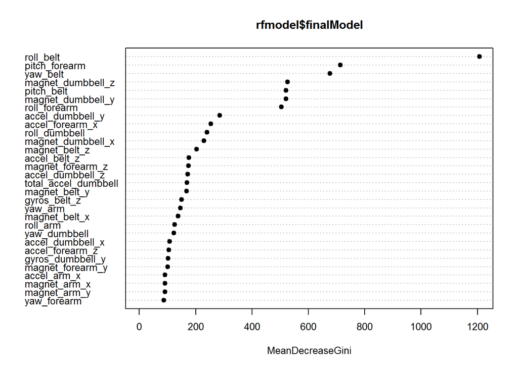

```r
varImpPlot(rfmodel$finalModel, cex = 0.8, pch=19)
```

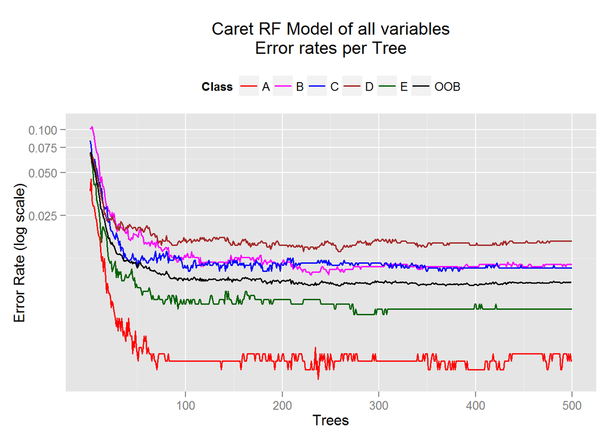

```r
errorRatePlot(rfmodel$finalModel$err.rate,
           clrs = c("red", "magenta", "blue", "brown", "darkgreen", "black"),
           fontsize = 12,
           title = "Caret RF Model of all variables\nError rates per Tree")
```